# Carpet Methods Code

## Prolog

```r
# PROLOG   ##############################################################################

# PROJECT: Seed Rain Methods
# PURPOSE: Data cleaning
#
# AUTHORS: Lauren Sullivan (llsull@msu.edu) & Lauren Shoemaker (lshoema1@uwyo.edu)
# COLLAB:  Melissa DeSiervo, Larissa Kahan
# EDITED:  20 April 2025
#
# FILES:   1) data/L0/MO_seedrain_raw.csv
#          2) data/LO/MO_seedweight_raw.csv
#          3) data/L0/CO_seedrain_raw.csv
#          4) data/L0/CO_seedweight_raw.csv
#
# NOTES:   creates "strict" datasets where we just focus on the species of interest
#             not herbivory or other species that were collected in the traps,
#             runs statistical analysis, plots exploratory figures and model-based figures
#
# NEXT STEPS: estimate slopes from mass by recovery fig (Fig 3), decide on MO post-sticky


# PROLOG   ##############################################################################
```

```r
# clear workspace
rm(list=ls())

# working directory
# set working directory to "source file location"

# libraries
library(tidyverse)
library(RColorBrewer)
library(viridis)
library(cowplot)
library(glmmTMB)
library(ggeffects) #for ggpredict()
library(emmeans) # for post-sticky comparison

# data
mo <- read_csv("../data/L0/MO_seedrain_raw.csv")
mo_mass <- read_csv("../data/L0/MO_seedweight_raw.csv")

co <- read_csv("../data/L0/CO_seedrain_raw.csv")
co_mass <- read_csv("../data/L0/CO_seedweight_raw.csv")
```

## Data Cleaning

Clean and combine all data from CO and MO sites - both the recovery and the seed mass data.

Missouri data cleaning

```r
# clean up treatment names and times

mo$time_month[mo$time_month == '1 month'] <- 1
mo$time_month[mo$time_month == '2 month'] <- 2
mo$time_month[mo$time_month == '1 week'] <- 0.25

mo$time_month <- as.numeric(mo$time_month)


# clean recovery data to just be the species we selected, not the extra
#      seeds we caught throughout the experiment

mo_slim <- mo %>%
  filter(species == "LESCAP" | species == "DESCAN" | species == "TRIPER" |
         species == "SCHSCO" | species == "ECHANG" | species == "SPOHET" |
         species == "RUDHIR" | species == "CORTIN")


#we used ECHPAL, not ECHANG - so update data
mo_slim$species[mo_slim$species == 'ECHANG'] <- "ECHPAL"

# clean seed mass data
mo_mass_small <- mo_mass %>%
  group_by(species) %>%
  dplyr::summarize(mean_1seed = mean(lot_mass_g)/25,
                   sd_1seed = sd(lot_mass_g)/25)

mo_mass_small # missouri seed mass mean and sd
```

```
## # A tibble: 8 × 3
##   species mean_1seed   sd_1seed
##   <chr>        <dbl>      <dbl>
## 1 CORTIN   0.000215  0.0000136
## 2 DESCAN   0.00442   0.000302
## 3 ECHANG   0.00460   0.000183
## 4 LESCAP   0.00328   0.0000986
## 5 RATPIN   0.00025   0.0000102
## 6 SCHSCO   0.00183   0.000114
## 7 SPOHET   0.00200   0.0000870
## 8 TRIPER   0.0000248 0.00000169
```

```r
# rename species to match recovery data
mo_mass_small$species[mo_mass_small$species == 'RATPIN'] <- "RUDHIR"
mo_mass_small$species[mo_mass_small$species == 'ECHANG'] <- "ECHPAL"
```

Colorado data cleaning

```r
# clean up treatment names and times

co$treatment[co$treatment == 's'] <- "sticky"
co$treatment[co$treatment == 'c'] <- "carpet"


# clean recovery data to just be the species we selected, not the extra
#      seeds we caught throughout the experiment

co_slim <- co %>%
  filter(species != ("various"))

co_mass_small <- co_mass %>%
  pivot_longer(
    cols = afrut:yglau,
    names_to = "species",
    values_to = "mass"
  ) %>%
  group_by(species) %>%
  dplyr::summarize(mean_1seed = mean(mass)/25,
                   sd_1seed = sd(mass)/25)

co_mass_small # colorado seed mass mean and sd
```

```
## # A tibble: 8 × 3
##   species mean_1seed  sd_1seed
##   <chr>        <dbl>     <dbl>
## 1 afrut     0.00754  0.000243
## 2 bdact     0.0118   0.000555
## 3 bgrac     0.000540 0.0000732
## 4 dpurp     0.00154  0.0000595
## 5 hannu     0.00675  0.000330
## 6 origi     0.000759 0.0000255
## 7 sangu     0.00084  0.0000444
## 8 yglau     0.0199   0.000518
```

```r
#rename species to match recovery data
co_mass_small$species[co_mass_small$species == 'afrut'] <- "a.fruticosa"
co_mass_small$species[co_mass_small$species == 'bdact'] <- "b.dactyloides"
co_mass_small$species[co_mass_small$species == 'bgrac'] <- "b.gracilis"
co_mass_small$species[co_mass_small$species == 'dpurp'] <- "d.purpurea"
co_mass_small$species[co_mass_small$species == 'hannu'] <- "h.annuus"
co_mass_small$species[co_mass_small$species == 'origi'] <- "s.rigida"
co_mass_small$species[co_mass_small$species == 'sangu'] <- "s.angustifolium"
co_mass_small$species[co_mass_small$species == 'yglau'] <- "y.glauca"
```

Join data together

```r
### Create full dataset with both sites

dat_all <- full_join(mo_slim, co_slim)

list(unique(dat_all$species))
```

```
## [[1]]
##  [1] "RUDHIR"          "CORTIN"          "TRIPER"          "ECHPAL"
##  [5] "DESCAN"          "LESCAP"          "SCHSCO"          "SPOHET"
##  [9] "a.fruticosa"     "b.gracilis"      "b.dactyloides"   "d.purpurea"
## [13] "h.annuus"        "s.rigida"        "s.angustifolium" "y.glauca"
```

```r
# create a %consumed column

dat_all$pct_recovered <- dat_all$number_recovered/dat_all$number_original
dat_all$time_month <- as.factor(dat_all$time_month)
```

## Exploratory Figures

Exploratory figures of recovery rates by collection type and by site.

First lets look at the percent recovered.

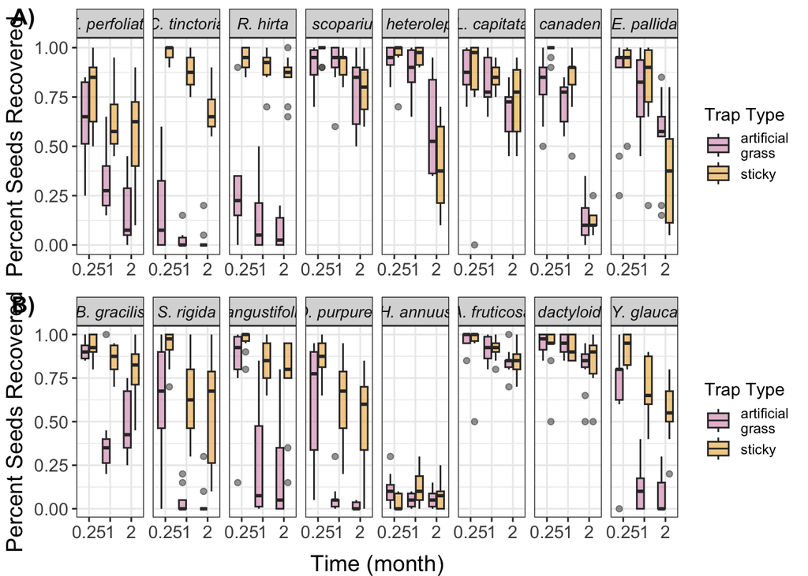

Next let’s look at the LRR of recovery of carpets relative to sticky traps, so positive values mean the sticky traps retain more, and the negative values mean the carpets retain more.

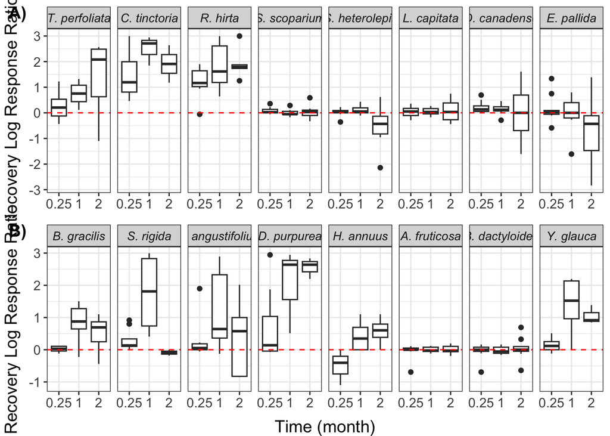

## Analysis

Explore how proportion seed removal is a function of seed size, trap method and time with a random effect for block nested within site.

```r
# Statistical Model
mod1 <- glmmTMB(pct_recovered ~ treatment * mean_1seed + time_month + (1|site/block),
                data = dat_full,
                weights = number_original,
                family = binomial)
summary(mod1)
```

```
##  Family: binomial  ( logit )
## Formula:
## pct_recovered ~ treatment * mean_1seed + time_month + (1 | site/block)
## Data: dat_full
## Weights: number_original
##
##      AIC      BIC   logLik deviance df.resid
##  11399.1  11433.1  -5692.5  11385.1      953
##
## Random effects:
##
## Conditional model:
##  Groups     Name        Variance Std.Dev.
##  block:site (Intercept) 0.04486  0.2118
##  site       (Intercept) 0.06112  0.2472
## Number of obs: 960, groups:  block:site, 20; site, 2
##
## Conditional model:
##                              Estimate Std. Error z value Pr(>|z|)
## (Intercept)                   0.58882    0.18509    3.18  0.00147 **
## treatmentsticky               1.55769    0.04420   35.24  < 2e-16 ***
## mean_1seed                  102.51826    5.68285   18.04  < 2e-16 ***
## time_month                   -0.85745    0.02366  -36.24  < 2e-16 ***
## treatmentsticky:mean_1seed -115.20429    7.66727  -15.03  < 2e-16 ***
## ---
## Signif. codes:  0 '***' 0.001 '**' 0.01 '*' 0.05 '.' 0.1 ' ' 1
```

Summary stats and main text figure to represent the significant trap type * seed mass interaction using model predicted values.

```
## # A tibble: 2 × 3
##   treatment mean_recovered sd_recovered
##   <fct>              <dbl>        <dbl>
## 1 carpet             0.518        0.179
## 2 sticky             0.741        0.130
```

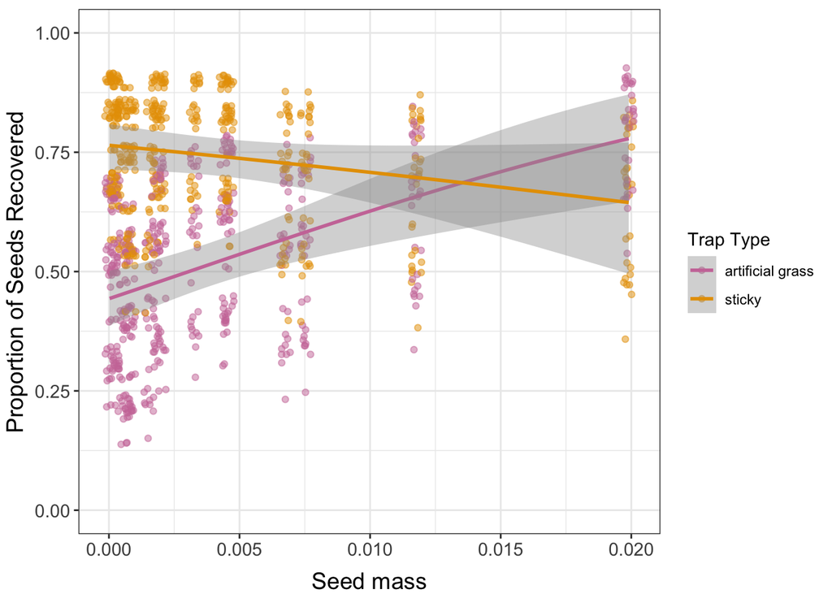

Examining model output and different comparisons we want to report and visualize. In particular, use emmeans to examine comparisons among trap types at different seed masses.

```r
# Contrasts for different seed masses
EM <- emmeans::emmeans(mod1, ~treatment |mean_1seed, at = list(mean_1seed = c(0)))
pairs(EM) ### average results over random effects ##
```

```
## mean_1seed = 0:
##  contrast        estimate     SE  df z.ratio p.value
##  carpet - sticky    -1.56 0.0442 Inf -35.238  <.0001
##
## Results are given on the log odds ratio (not the response) scale.
```

```r
EM2 <- emmeans::emmeans(mod1, ~treatment |mean_1seed, at = list(mean_1seed = c(0.02)))
pairs(EM2) ### average results over random effects ##
```

```
## mean_1seed = 0.02:
##  contrast        estimate    SE  df z.ratio p.value
##  carpet - sticky    0.746 0.129 Inf   5.773  <.0001
##
## Results are given on the log odds ratio (not the response) scale.
```

Post-sticky analysis from MO. How seed recovery varies across trap type when traps are out for one month (stick, artificial grass and post-sticky)

```r
mod2 <- glmmTMB(pct_recovered ~ treatment + (1|block) + (1|species),
                data = dat_ps,
                family = binomial)
summary(mod2)
```

```
##  Family: binomial  ( logit )
## Formula:          pct_recovered ~ treatment + (1 | block) + (1 | species)
## Data: dat_ps
##
##      AIC      BIC   logLik deviance df.resid
##    293.9    311.3   -142.0    283.9      235
##
## Random effects:
##
## Conditional model:
##  Groups  Name        Variance  Std.Dev.
##  block   (Intercept) 7.463e-10 2.732e-05
##  species (Intercept) 2.357e-01 4.855e-01
## Number of obs: 240, groups:  block, 10; species, 8
##
## Conditional model:
##                           Estimate Std. Error z value Pr(>|z|)
## (Intercept)                 0.1524     0.2875   0.530    0.596
## treatmentartificial grass   0.1658     0.3273   0.507    0.612
## treatmentsticky             1.6473     0.3943   4.178 2.94e-05 ***
## ---
## Signif. codes:  0 '***' 0.001 '**' 0.01 '*' 0.05 '.' 0.1 ' ' 1
```

Figure with predicted data

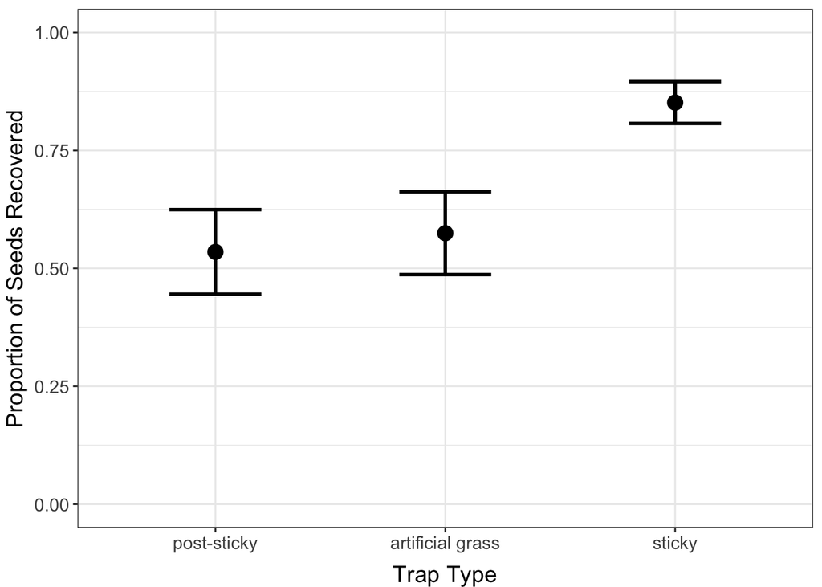

## Supplemental figure

Explore the predicted outcome for all factors (trap type, mass, time and site)

```
##  Family: binomial  ( logit )
## Formula:
## pct_recovered ~ treatment * mean_1seed + Month + (1 | site/block)
## Data: dat_full_renamed
## Weights: number_original
##
##      AIC      BIC   logLik deviance df.resid
##  11399.1  11433.1  -5692.5  11385.1      953
##
## Random effects:
##
## Conditional model:
##  Groups     Name        Variance Std.Dev.
##  block:site (Intercept) 0.04486  0.2118
##  site       (Intercept) 0.06112  0.2472
## Number of obs: 960, groups:  block:site, 20; site, 2
##
## Conditional model:
##                              Estimate Std. Error z value Pr(>|z|)
## (Intercept)                   0.58882    0.18509    3.18  0.00147 **
## treatmentsticky               1.55769    0.04420   35.24  < 2e-16 ***
## mean_1seed                  102.51826    5.68285   18.04  < 2e-16 ***
## Month                        -0.85745    0.02366  -36.24  < 2e-16 ***
## treatmentsticky:mean_1seed -115.20429    7.66727  -15.03  < 2e-16 ***
## ---
## Signif. codes:  0 '***' 0.001 '**' 0.01 '*' 0.05 '.' 0.1 ' ' 1
```

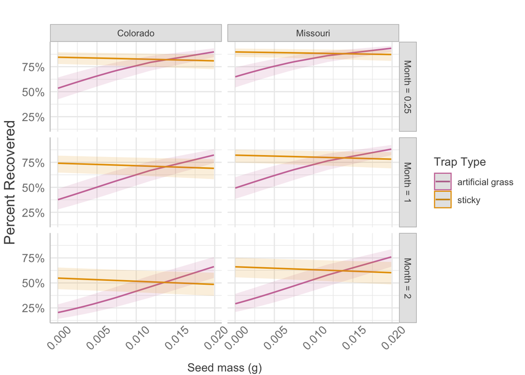